# Assessing Goodness of Fit

Oscar Rodriguez de Rivera

In this worksheet we will discuss how to assess graphically whether a random sample follows the normal distribution and we will explore the chi-squared goodness of fit test.

### Assessing normality

As we have studied before, we can use graphical ways, like histograms and boxplots, to represent the data and investigate their distribution. A graphical technique to inspect whether a dataset follows the normal distribution or not is a quantile-quantile plot (qq-plot). A qq-plot is a graph which plots the quantiles of one distribution against the quantiles of another as points. The idea is that if the two distributions have similar shapes, their points will lie mainly along a straight line. If the two distributions are different, then the points will not lie near a straight line.

- **Exercise 1.1**

Consider the anorexia dataset we have studied before. Explore whether the data follow the normal distribution.

**Solution:**

To assess whether the anorexia data fit the normal distribution we can use the qqnorm() and qqline() built-in functions of R.

First load the data set and create two vectors of observations for weight before and after :

```r
library("MASS")
data(anorexia)
attach(anorexia)
x1<-Prewt;x2<-Postwt
```

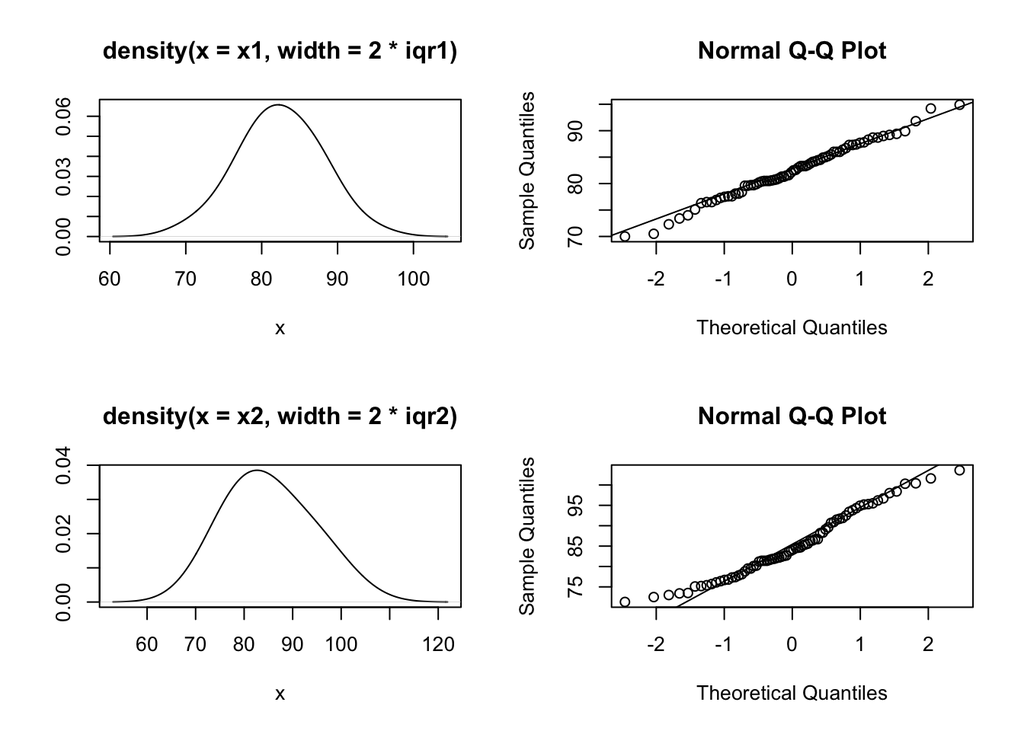

```r
iqr1 <- summary(x1)[5] - summary(x1)[2]
iqr2 <- summary(x2)[5] - summary(x2)[2]
par(mfrow = c(2, 2))
plot(density(x1,width=2*iqr1), xlab = "x", ylab = "", type = "l")
qqnorm(x1);qqline(x1)
plot(density(x2,width=2*iqr2), xlab = "x", ylab = "", type = "l")
qqnorm(x2);qqline(x2)
```

What do you notice about the qq-plots?

In both plots the points in the tails deviate from the straight line. It is a matter of judgement whether this is sufficient to indicate non-normality.

### Goodness of fit test

The goodness of fit test is a way to assess the distribution of a dataset; it measures how well a random sample fits a (theoretical) probability model. In a goodness of fit test we match empirical frequencies with fitted ones according to a specific probability model.

In a goodness of fit test the H0 will specify the probability distribution and the alternative H1 will be that H0 is not true. Then we reject $\text{H}_0$ at the $100\alpha\%$ level when $T > \chi _{J−1,\alpha}^2$.

- **Exercise 2.1**

Suppose that a pair of dice are thrown 180 times and the number of 6s, denoted by Y, is recorded:

| Category (j) | 1 | 2 | 3 |
| --- | --- | --- | --- |
| Number of 6s | 0 | 1 | 2 |
| Frequency($O_j$) | 105 | 70 | 5 |

The probability distribution of Y, if the dice are fair, is given by:

$$\text{Pr}(Y=0) = 5/6 \times 5/6 = 25/36\\
\text{Pr}(Y=1) = 2 \times 1/6 \times 5/6 = 10/36\\
\text{Pr}(Y=2) = 1/6 \times 1/6 = 1/36$$
Test the following hypothesis: $\text{H}_0$ : dice are fair versus $\text{H}_1$ : dice are not fair

**Solution:** first create two vectors, one of observed frequencies and one of the theoretical probabilities, then use the `chisq.test()` built-in function of R to carry out the test:

```r
six.freq<-c(105, 70, 5)
six.prob<-c(25/36,10/36,1/36)
chisq.test(six.freq, p=six.prob)
```

```
##
##  Chi-squared test for given probabilities
##
## data:  six.freq
## X-squared = 11.2, df = 2, p-value = 0.003698
```

The value of the test statistic is: 11.2 on 2 degrees of freedom. Its p-value is: 0.003698.

Can the null hypothesis be rejected? If so, at what significance level?

```r
#The p-value of 0.003698 indicates that the null hypothesis can be rejected at the 5% and 1% significance levels, indicating that there is strong evidence to support the alternative hypothesis.
```

What can you conclude about the dice?

```r
#We can conclude that the dice are not fair.
```

- **Exercise 2.1**

Suppose that a dataset for the number of thunderstorms reported in a one-month period by 100 meteorological stations gives the following information:

| Category (j) | 1 | 2 | 3 | 4 | 5 | 6 |
| --- | --- | --- | --- | --- | --- | --- |
| Number of storms | 0 | 1 | 2 | 3 | 4 | 5 |
| Frequency($O_j$) | 22 | 37 | 20 | 13 | 6 | 2 |

Test whether the data come from the Poisson distribution: $\text{H}_0$: data come from a Poisson distribution vs $\text{H}_1$: data do not come from a Poisson distribution

**Solution:** First, we need to estimate the Poisson parameter λ using the sample mean. Create two vectors of number of thunderstorms and observed frequency and hence calculate the sample mean:

```r
thunder.freq<-c(22,37,20,13,6,2)
thunder.no<-c(0,1,2,3,4,5)
data.thunder<-rep(thunder.no, thunder.freq)
mean.thunder<-mean(data.thunder)
mean.thunder
```

```
## [1] 1.5
```

The point estimate of $\lambda$ is $\hat{\lambda}$ = 1.5.

Now find the expected frequencies under the null hypothesis. First calculate the Poisson probabilities for 0,1,2,3,4 and 5 thunderstorms, find the probability for > 5 thunderstorms and create a vector of theoretical probabilities for categories 0,1,2,3,4,5,> 5 thunderstorms. Update the observed frequency vector to indicate zero frequency for > 5 thunderstorms.

```r
probs<-dpois(thunder.no,lambda=mean.thunder)
sump<-sum(probs)
probsU<-c(probs,1-sump)
thunder.freqU<-c(22,37,20,13,6,2,0)
```

Before calculating the test statistic, check that all expected frequencies are > 1 and almost all are > 5. These conditions are required for the approximation to the chi-squared distribution to be valid.

```r
expected<-100*probsU   #multiply probabilities by total no. of thunderstorms
expected
```

```
## [1] 22.3130160 33.4695240 25.1021430 12.5510715  4.7066518  1.4119955  0.4455981
```

The expected frequency for > 5 thunderstorms is not > 1 so combine the categories for 5 and > 5 thunderstorms into $\geq$ 5 thunderstorms and repeat the calculations to find the probability for this final category.

```r
thunder.no1<-c(0,1,2,3,4)
probs1<-dpois(thunder.no1,lambda=mean.thunder)
sump1<-sum(probs1)
probsU1<-c(probs1,1-sump1)
```

To test the above hypothesis we cannot use the p-value from the `chisq.test()` function directly because the degrees of freedom are not corrected for any estimated parameters; remember that we estimated the mean and so the degrees of freedom reduce by 1.

```r
chisq.test(thunder.freq,p=probsU1)
```

```
##
##  Chi-squared test for given probabilities
##
## data:  thunder.freq
## X-squared = 1.7962, df = 5, p-value = 0.8766
```

To test the hypothesis, the test statistic t = 1.7962 should be compared with the upper-tail critical value from $\chi_4^2$; this can be obtained using:

```r
qchisq(0.05,df=4,lower.tail = FALSE)
```

```
## [1] 9.487729
```

What do you conclude?

```r
#The critical value at the 5\% significance level is 9.487729 so the null hypothesis cannot be rejected at this level. There is therefore no evidence against the Poisson distribution as a model for these data.
```

### Exercises

- **Exercise 3.1**

Suppose that a survey takes place to learn about the smoking habits of undergraduate students of the University of Kent. The random sample consists of 200 students. The results are summarised in the following table:

| Smoking habits | Heavy | Regularly | Occasionally | Never |
| --- | --- | --- | --- | --- |
| Frequency($O_j$) | 25 | 116 | 43 | 16 |

Also, suppose that the Student Union has some UK-wide statistics available on the smoking habits of students:

| Smoking habits | Heavy | Regularly | Occasionally | Never |
| --- | --- | --- | --- | --- |
| Percentage of students | 13% | 38% | 15% | 34% |

Does the random sample support the above statistics?

The null hypothesis is that smoking habits of University of Kent students are the same as those of the UK student population; the alternative hypothesis is that smoking habits of University of Kent students are different from those of the UK student population.

Use the chisq.test() function to carry out the test: